# Week 1: Introduction to R

Wednesday, January 13, 2021 @ 1:30 PM HST

**Disclaimer: These labs rely heavily on those developed by Mike Whitlock for his BIOL 300 course at UBC https://www.zoology.ubc.ca/~whitlock/bio300/.** In some cases I have used his material *verbatim*, in other cases I have heavily modified them.

## Goals

- Learning how to start with *RStudio Cloud*
- Use the command line
- Use functions in *R*
- Learn how to increase the power *R* with packages
- Use vectors
- Use data frames

## Learning the Tools

### What is *R*?

*R* is a computer program that allows an extraordinary range of statistical calculations. It is a free program, mainly written by voluntary contributions from statisticians around the world. *R* is available on most operating systems, including Windows, Mac OS, and Linux.

*R* can make graphics and do statistical calculations. It is also a full-fledged computing language. In this manual, we will only scratch the surface of what *R* can do.

### What is *RStudio*?

*RStudio* is a separate program, also free, that provides a more elegant front end for *R*. *RStudio* allows you to easily organize separate windows for *R* commands, graphic, help, etc. in one place.

For this course, you won’t need *R* and *RStudio* installed on your own device because we will work in *RStudio Cloud*. However, if you wish to install them on your device, go to https://rstudio.com/products/rstudio/download/ for instructions about getting set up.

### What is *RStudio Cloud*?

From [here](https://docs.rstudio.com/other/rstudio-cloud/):

> *RStudio Cloud* is a hosted version of *RStudio* in the cloud that makes it easy for professionals, hobbyists, trainers, teachers and students to do, share, teach and learn data science using R.

> Create your analyses using *RStudio* directly from your browser - there is no software to install and nothing to configure on your computer.

#### Resources

> [*RStudio Cloud*](https://rstudio.cloud) provides many learning materials: [interactive tutorials](https://rstudio.cloud/learn/primers) covering the basics of data science, [cheatsheets](https://rstudio.cloud/learn/cheat-sheets) for working with popular *R* packages and a [guide to using *RStudio Cloud*](https://rstudio.cloud/learn/guide).

### Getting started

1. We have set a class Workspace called biol220. You can join the Workspace by clicking on the following link (you only need to do this once).

https://rstudio.cloud/spaces/113535/join?access_code=QCiTAUF7JIK3T3tuCvXbnu%2FA3YY7kKkuyNRa%2BhzU

**Important**: Make sure you register using your userid@hawaii.edu account, not a personal gmail account. If you accidentally, use your personal account, let me know. I will delete it while you register with the university account.

2. Once you’re logged in, the Workspace will looking something like this:

[figure not shown]

Each item listed under “All Projects” is a “Project” within the biol220 Workspace. Each week I will create a Project template that you will copy and work from (you cannot edit the original).

3. To create your own, click “Copy” to the right of “lab01”. Next week, it’ll be “lab02”, then “lab03”, etc.

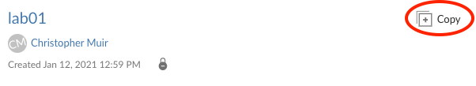

Then click OK

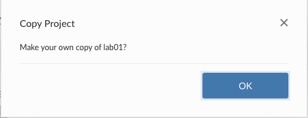

4. Once the Project is copied and deployed, rename the Project from “lab01” to include your name like this:

“lab01-muir-chris”

When you start *RStudio Cloud*, it will automatically start *R* as well. You run *R* inside *RStudio Cloud*.

After you have started *RStudio Cloud*, you should see a new window with a menu bar at the top and three main sections. One of the sections is called the “Console” – this is where you type commands to give instructions to *R* and typically where you see *R*’s answers to you.

Another important corner of this window can show a variety of information. Most importantly to us, this is where graphics will appear, under the tab marked “Plots”.

### The command line

When you start *RStudio Cloud*, you’ll see a corner of the window called the “Console.” By the default the console window is in the bottom left of the *RStudio* screen.

You can type commands in this window where there is a prompt (which will look like a `>` sign at the bottom of the window). The Console has to be the selected window. (Clicking anywhere in the Console selects it.)

The `>` prompt is *R*’s way of inviting you to give it instructions. You communicate with *R* by typing commands after the `>` prompt.

Type “`2+2`” at the `>` prompt, and hit return. You’ll see that *R* can work like a calculator (among its many other powers). It will give you the answer, `4`, and it will label that answer with `[1]` to indicate that it is the first element in the answer. (This is sort of annoying when the answers are simple like this, but can be very valuable when the answers become more complex.)

Remember, you don’t type the `>` sign. The `>` is the prompt that *R* gives saying it is ready for input. We reproduce it here so you can see which is input (in blue) and which is output (in black or red).

```r
2 + 2
```

```
## [1] 4
```

You can use a wide variety of math functions to make calculations here, e.g., `log()` calculates the log of a number:

```r
log(42)
```

```
## [1] 3.73767
```

(By default, this gives the natural log with base $e$.)

Parentheses are used both as a way to group elements of the calculation and also as a way to denote the arguments of functions. (The “arguments” of a function are the set of values given to it as input.) For example, `log(3)` is applying the function `log()` to the argument `3`.

```r
sqrt(42)
```

```
## [1] 6.480741
```

To calculate a value with an exponent, used the `^` symbol. For example $4^3$ is written as:

```r
4 ^ 3
```

```
## [1] 64
```

Note how *R* ignores white space when it’s not in quotes (we’ll come back to quotes later):

```r
4^3
```

```
## [1] 64
```

```r
4  ^  3
```

```
## [1] 64
```

Of course, many math functions can be combined to give an almost infinite possibility of mathematical expressions. For example,

$$\frac{1}{\sqrt{2 \pi (3.1)^2}} e ^ {-\frac{(12 - 10.7) ^ 2}{2 \times 3.1}}$$

can be calculated with

```r
(1 / (sqrt(2 * pi * (3.1) ^ 2))) * exp(-(12 - 10.7) ^ 2 / (2 * 3.1))
```

```
## [1] 0.09798692
```

### Saving your code

When you analyze your own data, we strongly recommend that you keep a record of all commands used, along with copious notes, so that weeks or years later you can retrace the steps of your earlier analysis.

In *RStudio Cloud*, you can create a plain text file (sometimes called a script), which contains *R* commands that can be reloaded and used at a later date. We have created a scratch file where you can enter and save your commands while you’re learning the tools. Click on “scratch.R” in the lower-right:

[figure not shown]

That will open a mostly blank text file above the Console that looks like this:

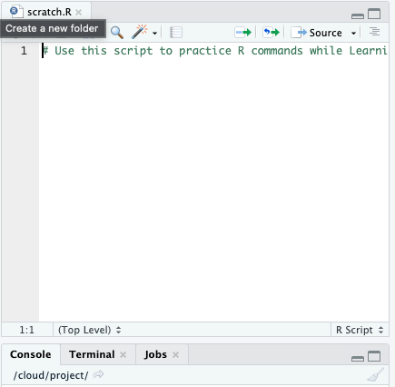

You can copy and paste any commands that you want from the Console, or type directly here. (When you copy and paste, it’s better to not include the `>` prompt in the script.) If you want to keep this script for later, just hit “Save” under the “File” menu. In the future you can open this file in all the normal ways to have those commands available for use again.

It is best to type all your commands in the script window and run them from there, rather than typing directly into the console. This lets you save a record of your session so that you can more easily re-create what you have done later.

FYI, if you want to create a new, blank *R* script, here’s how. Under the menu at the top, choose “File”, then “New File”, and then “R Script”. This will create a new section in *RStudio Cloud* with the temporary name “Untitled1” (or similar).

### Comments

In scripts, it can be very useful to save a bit of text which is not to be evaluated by *R*. You can leave a note to yourself (or a colleague) about what the next line is supposed to do, what its strengths and limitations are, or anything else you want to remember later. To leave a note, we use “comments”, which are a line of text that starts with the hash symbol `#`. Anything on a line after a # will be ignored by *R*.

```r
# This is a comment. Running this in R will
# have no effect.
```

### Functions

Most of the work in *R* is done by functions. A function has a name and one or more arguments. For example, `log(4)` is a function that calculates the log in base $e$ for the value `4` given as input.

Sometimes functions have optional input arguments. For the function `log()`, for example, we can specify the optional input argument base to tell the function what base to use for the logarithm. If we don’t specify the base variable, it has a default value of `base = e`. To get a log in base 10, for example, we would use:

```r
log(4, base = 10)
```

```
## [1] 0.60206
```

### Defining variables

In *R*, we can store information of various sorts by assigning them to variables. For example, if we want to create a variable called `x` and give it a value of `4`, we would write

```r
x <- 4
```

The middle bit of this – a less than sign and a hyphen typed together to make something that looks a little like a left-facing arrow – tells *R* to assign the value on the right to the variable on the left. After running the command above, whenever we use `x` in a command it would be replaced by its value `4`. For example, if we add `3` to `x`, we would expect to get `7`.

```r
x + 3
```

```
## [1] 7
```

Variables in *R* can store more than just simple numbers. They can store lists of numbers, functions, graphics, etc., depending on what values get assigned to the variable.

We can always reassign a new value to a variable. If we now tell *R* that `x` is equal to 32

```r
x <- 32
```

then `x` takes its new value:

```r
x
```

```
## [1] 32
```

### Names

Naming variables and functions in *R* is pretty flexible.

A name has to start with a letter, but that can be followed by letters or numbers. There can’t be any spaces, though.

Names in *R* are case-sensitive, which means that `Weights` and `weights` are completely different things to *R*. This is a common and incredibly frustrating source of errors in *R*.

It’s a good idea to have your names be as descriptive as possible, so that you will know what you meant later on when looking at it. (However, if they get too long, it becomes painful and error prone to type them each time we use them, so this, as with all things, requires moderation.)

### Vectors

```r
 c(78, 85, 64, 54, 102, 98.6)
```

```
## [1]  78.0  85.0  64.0  54.0 102.0  98.6
```

`c()` is a function that creates a vector, containing the items given in its arguments. To help you remember, you could think of the function `c()` meaning to “**c**ombine” some elements into a vector.

Let’s add a little extra here to make the computer remember this vector. Let’s assign it to a variable, called `temperatureF` (because these numbers are actually a set of temperatures in degrees Fahrenheit):

```r
temperatureF <- c(78, 85, 64, 54, 102, 98.6)
```

The combination of the less than sign and the hyphen makes an arrow pointing from right to left—this tells *R* to assign the stuff on the right to the name on the left. In this case we are assigning a vector to the variable `temperatureF`.

Inputting this to *R* causes no obvious output, but *R* will now remember this vector of temperatures under the name `temperatureF`. We can view the contents of the vector `temperatureF` by simply typing its name:

```r
temperatureF
```

```
## [1]  78.0  85.0  64.0  54.0 102.0  98.6
```

The power of vectors is that sometimes *R* can do the same calculation on all elements of a vector with one command. For example, to convert a temperature in Fahrenheit to Celsius, we would want to subtract `32` and multiply times `5/9`. We can do that for all the numbers in this vector at once:

```r
temperatureC <- (temperatureF - 32) * 5 / 9
temperatureC
```

```
## [1] 25.55556 29.44444 17.77778 12.22222 38.88889 37.00000
```

To pull out one of the numbers in this vector, we add square brackets after the vector name, and inside those brackets put the index of the element we want. (The “index” is just a number giving the relative location in the vector of the item we want. The first item has index `1`, etc.) For example, the second element of the vector `temperatureC` is

```r
temperatureC[2]
```

```
## [1] 29.44444
```

One of the ways to slip up in *R* is to confuse the [square brackets] which pull out an element of a vector, with the (parentheses) , which is used to enclose the arguments of a function.

Vectors can also operate mathematically with other vectors. For example, imagine you have a vector of the body weights of patients before entering hospital (`weight_before_hospital`) and another vector with the same patient’s weights after leaving hospital (`weight_after_hospital`). You can calculate the change in weight for all these patients in one command, using vector subtraction:

```r
weight_before_hospital <- c(100, 102)
weight_after_hospital <- c(98, 99)

weight_change_during_hospital <- weight_before_hospital - weight_after_hospital
```

The result will be a vector that has each patient’s change in weight.

### Basic calculation examples

In this course, we’ll learn how to use a few dozen functions, but let’s start with a couple of basic ones.

The function `mean()` does just what it sounds like: it calculates the sample mean (that is, the average) of the vector given to it as input. For example, the mean of the vector of the temperatures in degrees Celsius from above is 26.81481:

```r
mean(temperatureC)
```

```
## [1] 26.81481
```

Another simple (and simply named) function calculates the sum of all numbers in a vector: `sum()`.

```r
sum(temperatureC)
```

```
## [1] 160.8889
```

To count the number of elements in a vector, use `length()`.

```r
length(temperatureC)
```

```
## [1] 6
```

This shows that there are 6 temperature values in the vector that make up the vector `temperatureC`.

### Extending *R*’s capabilities

*R* has a lot of power in its basic form, but one of the most important parts about *R* is that it is expandable by the work of other people. These expansions are usually released in “packages”.

Each package needs to be installed on your computer only once, but to be used it has to be loaded into *R* during each session.

To install a package in *RStudio Cloud*, click on the packages tab from the sub-window with tables for Files, Plots, Packages, Help, and Viewer. Immediately below that will be a button labeled “Install” – click that and a window will open.

In the second row (labeled “Packages”), type **ggplot2** (without the quotation marks). Make sure the box for “Install dependencies” near the bottom is clicked, and then click the “Install” button at bottom right. This will install the graphics package **ggplot2**.

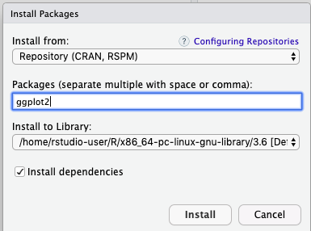

This only needs to be done once on a given computer or *RStudio Cloud* Workspace, and that package is permanently available.

There is another package that we will use in this course (and briefly today) called **dplyr**. I will always pre-install packages in the workspace prior to doing the lab, but I am showing you how to install additional packages for future references.

### Loading a package

Once a package is installed, it needs to be loaded into *R* during a session if you want to use it. You do this with a function called `library()`.

For this week’s labs, we will use the packages **dplyr** and **readr**. **dplyr** allows for easy modification of data frames; **readr** reads data into *R*. Before using the functions in these packages, we need to load them. We do this with the `library()` function. In the console, enter this

```r
library(dplyr)
library(readr)
```

### Set the working directory

The files on your workspace and computers are organized hierarchically into folders, or “directories.” Conveniently, in an *RStudio Cloud* Project, the Working Directory is the “project” folder where all your files are (wherever the folder “project.Rproj” is). You can check the the current directory using the `getwd()` command.

```r
getwd()
```

```
## [1] "/cloud/project"
```

FYI, it is convenient to tell *R* which directory to look for files at the beginning of a session, to minimize typing later. You can also set the working directory for *RStudio Cloud* from *RStudio Cloud*’s menu (the same directions apply to the Desktop version of *RStudio*). From the “Session” tab in the menu bar, choose “Set Working Directory”, and then “Choose Directory…” This will open a dialog box that will let you find and select the directory you want.

### Reading a file

In this course, we have saved the data in a “comma-separated variable” format. All files in this format ought to have “.csv” as the end of their file name. A CSV file is a plain text file, easily read by a wide variety of programs. Each row in the file (besides the first row) is the data for a given individual, and for each individual each variable is listed in the same order, separated by commas. It’s important to note that you can’t have commas anywhere else in the file, besides the separators.

The first row of a CSV file should be a “header” row, which gives the names of each variable, again separated by commas.

For examples in this tutorial, let’s use a data set about the passengers of the *RMS Titanic*. One of the data sets in the folder of data attached to this lab is called “titanic.csv”. This is a data set of 1313 passengers from the voyage of this ship, which contains information about some personal info about each passenger as well as whether they survived the accident or not.

To import a CSV file into *R*, use the `read_csv()` function as in the following command. (This assumes that you have set the working directory to the labs folder, as we described above.)

```r
titanic_data <- read_csv("data/titanic.csv")
```

To see if the data loads appropriately, you might want to run the command

```r
summary(titanic_data)
```

```
##  passenger_class        name                age            embarked
##  Length:1313        Length:1313        Min.   : 0.1667   Length:1313
##  Class :character   Class :character   1st Qu.:21.0000   Class :character
##  Mode  :character   Mode  :character   Median :30.0000   Mode  :character
##                                        Mean   :31.1942
##                                        3rd Qu.:41.0000
##                                        Max.   :71.0000
##                                        NA's   :680
##  home_destination       sex              survive
##  Length:1313        Length:1313        Length:1313
##  Class :character   Class :character   Class :character
##  Mode  :character   Mode  :character   Mode  :character
##
##
##
##
```

which will list all the variables and some summary statistics for each variable.

### Intro to data frames

A data frame is a way that *R* can store a data set on a number of individuals. A data frame is a collection of columns; each column contains the values of a single variable for all individuals. The values of each individual occur in the same order in all the columns, so the first value for one variable represents the same individual as the first value in the lists of all other variables.

The function `read_csv()` loads the data it reads into a data frame.

The data frame is usually given a name, which is used to tell *R*’s functions which data set to use. For example, in the previous section we read in a data set to a data frame that we called `titanic_data`. This data frame now contains information about each of the passengers on the *Titanic.* This data frame has seven variables, so it has seven columns (`passenger_class`, `name`, `age`, `embarked`, `home_destination`, `sex`, and `survive`).

Very importantly, we can grab one of the columns from a data frame by itself. We write the name of the data frame, followed by a `$`, and then the name of the variable.

For example, to show a list of the age of all the passengers on the *Titanic*, use

```r
titanic_data$age
```

```
## [1] 29.0000  2.0000 30.0000 25.0000  0.9167 47.0000
```

This will show a vector that has all the values for this variable `age`, one for each individual in the data set.

### Adding a new column

Sometimes we would like to add a new column to a data frame. The easiest way to do this is to simply assign a new vector to a new column name, using the `$`.

For example, to add the log of age as a column in the `titanic_data` data frame, we can write

```r
titanic_data$log_age <- log(titanic_data$age)
```

You can run the command `head(titanic_data)` to see that `log_age` is now a column in `titanic_data`.

### Choosing subsets of data

Sometimes we want to do an analysis only on some of the data that fit certain criteria. For example, we might want to analyze the data from the *Titanic* using only the information from females.

The easiest way to do this is to use the `filter()` function from the package **dplyr**. Reminder: make sure you have loaded **dplyr** it into *R* using `library()`:

```r
library(dplyr)
```

In the titanic data set there is a variable named `sex`, and an individual is female if that variable has value “`female`”. We can create a new data frame that includes only the data from females with the following command:

```r
filter(titanic_data, sex == "female")
```

| passenger_class | name | age | embarked | home_destination | sex | survive | log_age |
| --- | --- | --- | --- | --- | --- | --- | --- |
| 1st | Allen,MissElisabethWalton | 29.0000 | Southampton | StLouis,MO | female | yes | 3.3672958 |
| 1st | Allison,MissHelenLoraine | 2.0000 | Southampton | Montreal,PQ/Chesterville,ON | female | no | 0.6931472 |
| 1st | Allison,MrsHudsonJ.C.(BessieWaldoDaniels) | 25.0000 | Southampton | Montreal,PQ/Chesterville,ON | female | no | 3.2188758 |
| 1st | Andrews,MissKorneliaTheodosia | 63.0000 | Southampton | Hudson,NY | female | yes | 4.1431347 |
| 1st | Appleton,MrsEdwardDale(CharlotteLamson) | 58.0000 | Southampton | Bayside,Queens,NY | female | yes | 4.0604430 |
| 1st | Astor,MrsJohnJacob(MadeleineTalmadgeForce) | 19.0000 | Cherbourg | NewYork,NY | female | yes | 2.9444390 |
| 1st | Aubert,MrsLeontinePauline | NA | Cherbourg | Paris,France | female | yes | NA |
| 1st | Baxter,MrsJames(HeleneDeLaudeniereChaput) | 50.0000 | Cherbourg | Montreal,PQ | female | yes | 3.9120230 |
| 1st | Beckwith,MrsRichardLeonard(SallieMonypeny) | 47.0000 | Southampton | NewYork,NY | female | yes | 3.8501476 |
| 1st | Bishop,MrsDickinsonH.(HelenWalton) | 19.0000 | Cherbourg | Dowagiac,MI | female | yes | 2.9444390 |

[output cut: 453 more lines]

This new data fame will include all the same columns as the original `titanic_data`, but it will only include the rows for which the `sex` was “`female`”.

Note that the syntax here requires a double `==` sign. In *R* (and many other computer languages), the double equal sign creates a statement that can be evaluated as `TRUE` or `FALSE`, while a single equal sign may change the value of the first variable to the value on the right-hand side of the equal sign. Here we are asking, for each individual, whether `sex` is “`female`”, not assigning the value ”`female`” to the variable sex. So we use a double equal sign `==`.

## Questions for Lab Report

Your lab report is due **Wednesday, January 20, 2021 @ 1:30 PM HST". When you’re finished, save it, and Luke Campillo (TA) can access it on the Cloud.

1. For each week, use the *R* script called “report.R” to save the commands that you use to answer the questions. Use a `#` at the beginning of each comment line to record written answers.
1. Open the report.R file. Start by editing comments with your name at the top.

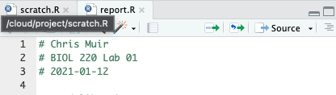

2. Save the script regularly as you work! To save, go to “File > Save” or use command-S shortcut.

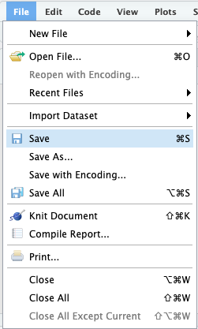

3. For each of the questions below, write the question number as a comment, followed by any *R* code you use to do the question, and give the answers as comments. It might look something like this

```r
# Chris Muir
# BIOL 220 Lab 01
# 2021-01-12

# Load libraries
library(dplyr)
library(readr)

# Questions

# 1. I followed directions to set up my lab report

# 2. Yes, I got the same answers!

# 3. Only text answers, no code
# Answer part 1
# Answer part 2

# 4. Text and code
# R does not like complex numbers
sqrt(-1)^2

# 5. More text and code, interleaved
# a.
x <- c(1, 2, 3) # you can also comment like this

# b.
mean(x)

# The mean of c(1, 2, 3) is 2. Here's what that means...
```

2. Run the **Learning the tools** commands in *R* from your “scratch.R” script. Did you get the same answers as shown in the text? (Answer “yes”, “no”, or a more detailed explanation. You don’t need to re-run all the code and output here.)
3. For each of the following, come up with a variable name that would be appropriate to use in *R* for the listed variable:

| Variable | Name in *R* |
| --- | --- |
| Body temperature in Celsius |  |
| How much aspirin is given per dose for a patient |  |
| Number of televisions per person |  |
| Height (including neck and extended legs) of giraffes |  |

4. Use *R* to calculate:
1. $15 \times 17$
2. $13^3$
3. $\text{log}_e(14)$ (natural log)
4. $\text{log}_{10}(100)$ (base 10 log)
5. $\sqrt{81}$
5. People are notoriously dishonest about revealing how often they perform antisocial behaviors like peeing in swimming pools. (In addition to being disgusting, the nitrogenous chemicals in urine combine with the pool’s chlorine to produce some toxic chemicals like trichloramine, the source of most skin irritations for swimmers.) A group of researchers (Jmaiff Blackstock *et al*. 2017) recently realized that an artificial sweetener called ACE passes out in urine unmetabolized and in known average quantities, and therefore by measuring ACE concentrations we can measure the amount of urine in a pool.

Here is a list of measurements, each from a different pool, of the concentration of ACE (measured in ng/L) for 23 different pools in Canada.

> 640, 1070, 780, 70, 160, 130, 60, 50, 2110, 70, 350, 30, 210, 90, 470, 580, 250, 310, 460, 430, 140, 1070, 130
1. In *R*, create a vector of these data, and name it appropriately.
2. What is the mean ACE concentration of these 23 pools?
3. Urine on average has 4000 ng ACE/ ml. Therefore to convert these measurements of ng ACE / L pool water to ml urine / L pool water we need to divide each by 4000. Make a new vector showing the concentration of urine per liter in these 23 pools. Give it a suitable name.
4. What is the mean concentration of urine per liter? How did this change relative to the mean measurement of ng ACE / L?
5. The arithmetic mean is calculated by adding up all the numbers and dividing by how many numbers there are. Calculate the mean of these numbers using `sum()` and `length()`. Did you get the same answer as with using `mean()`?
6. Use *R* to calculate the average amount of urine (in ml) in a 500,000 L pool.
6. Weddell seals live in Antarctic waters and take long strenuous dives in order to find fish to feed upon. Researchers (Williams *et al*. 2004) wanted to know whether these feeding dives were more energetically expensive than regular dives (perhaps because they are deeper, or the seal has to swim further or faster). They measured the metabolic costs of dives using the oxygen consumption of 10 animals (in ml O$_2$ / kg) during a feeding dive. Here are the data:

> 71.0, 77.3, 82.6, 96.1, 106.6, 112.8, 121.2, 126.4, 127.5, 143.1

For the same 10 animals, they also measured the oxygen consumption in non-feeding dives. With the 10 animals in the same order as before, here are those data:

> 42.2, 51.7, 59.8, 66.5, 81.9, 82.0, 81.3, 81.3, 96.0, 104.1
1. Make a vector for each of these lists, and give them appropriate names.
2. Confirm (using *R*) that both of your vectors have the same number of individuals in them.
3. Create a vector called `metabolism_difference` by calculating the difference in oxygen consumption between feeding dives and nonfeeding dives for each animal.
4. What is the average difference between feeding dives and nonfeeding dives in oxygen consumption?
5. Another appropriate way to represent the relationship between these two numbers would be to take the ratio of O$_2$ consumption for feeding dives over the O$_2$ consumption of nonfeeding dives. Make a vector which gives this ratio for each seal.
6. Sometimes ratios are easier to analyze when we look at the log of the ratio. Create a vector which gives the log of the ratios from the previous step. (Use the natural log.) What is the mean of this log-ratio?
7. The data file called “countries.csv” in the data folder contains information about all the countries on Earth[^1]. Each row is a country, and each column contains a variable.
1. Use `read_csv()` to read the data from this file into a data frame called `countries`.
2. Use `summary()` to get a quick description of this data set. What are the first three variables?
3. Using the output of `summary()`, how many countries are from Africa in this data set?
4. What kinds of variables (i.e., categorical or numerical) are continents, `cell_phone_subscriptions_per_100_people_2012`, `total_population_in_thousands_2015`, and `fines_for_tobacco_advertising_2014`? (Don’t go by their variable names – look at the data in the summary results to decide.)
5. Add a new column to your countries data frame that has the difference in ecological footprint between 2012 and 2000. What is the mean of this difference? (Note: this variable will have “missing data”, which means that some of the countries do not have data in this file for one or the other of the years of ecological footprint. By default, *R* doesn’t calculate a mean unless all the data are present. To tell R to ignore the missing data, add an option to the `mean()` command that says `na.rm=TRUE`. We’ll learn more about this later.)
8. Using the countries data again, create a new data frame called `africa_data`, that only includes data for countries in Africa. What is the sum of the `total_population_in_thousands_2015` for this new data frame?
[^1]: These data mainly come from the World Health Organization, but the Continent list comes from https://datahub.io/ and the ecological footprint and cell phone data come from http://www.nationmaster.com.